# Progress Memo 2

Final Project  
Data Science 1 with R (STAT 301-1)

Author

Ada Liu

Published

December 6, 2023

**Github Repo Link**

https://github.com/stat301-1-2023-fall/final-project-1-adacliu.git

## General Overview of the Distribution of Terroist Attacks

Terroist Attacks by Year

How has the frequency of terrorist attacks changed from 1970 to 2017?

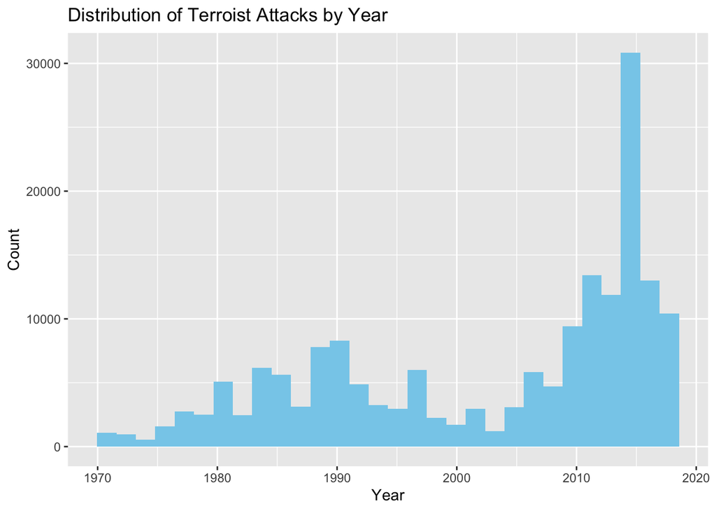

Terroist Attacks by Polity Score

Are there more attacks if a country has a higher or a lower Polity score?

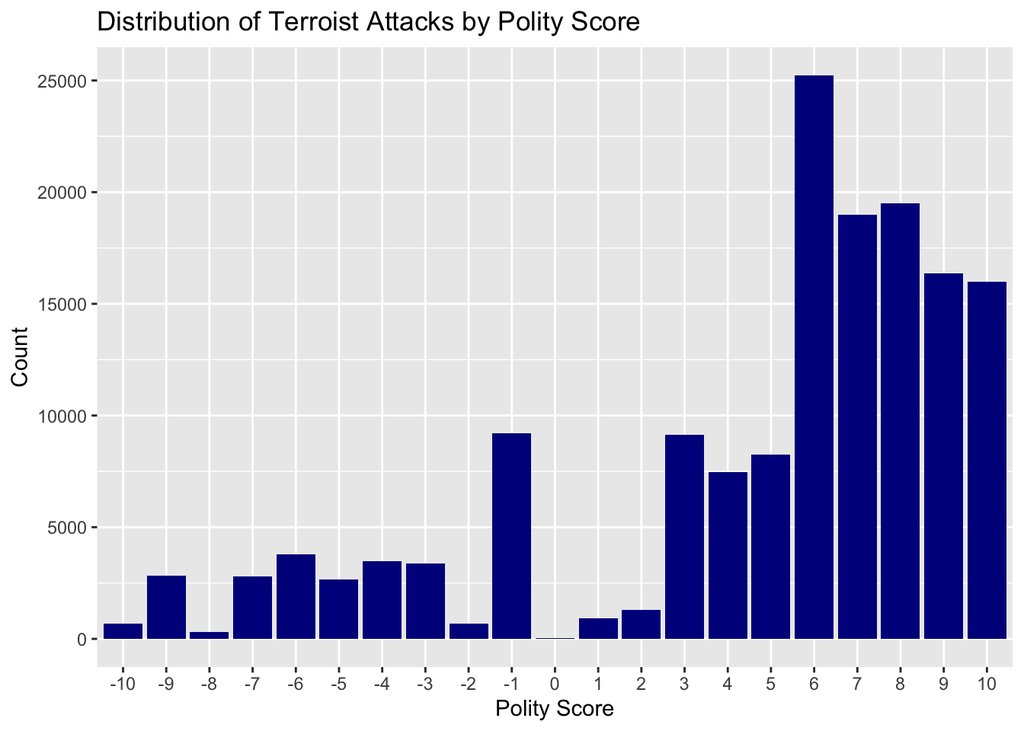

Frequency of Terrorist Attacks by Country

Where do most terrorist attacks occur?

| region_txt | n_attacks |
| --- | --- |
| Australasia & Oceania | 244 |
| Central America & Caribbean | 10248 |
| Central Asia | 563 |
| East Asia | 704 |
| Eastern Europe | 4718 |
| Middle East & North Africa | 48211 |
| North America | 3456 |
| South America | 18970 |
| South Asia | 44952 |
| Southeast Asia | 11923 |
| Sub-Saharan Africa | 15732 |
| Western Europe | 16069 |

To visizualize the frequncy of terrorist attacks by country

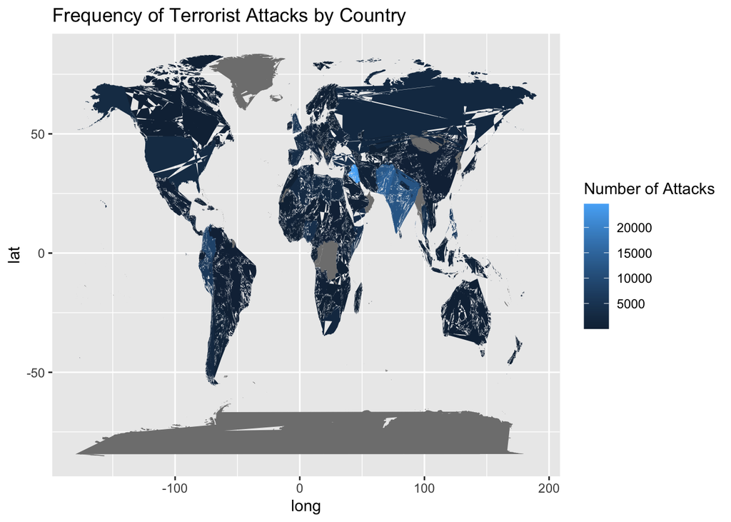

Looking at the number of terrorist attacks by region and by country, it is evident that Middle Eastern countries and South Asian countries have a much higher attacked rate. This may be due to the fact that many countries in these areas have unstable political regimes and have several groups fighting for control of the government.

## Exploring Attack Success vs. Political Stability

How does the political stability of a country, marked by its durability and polity scores, affect how likely a terrorist attack will be successful?

Basic overview of the distribution of successful and unsuccessful attacks

| Var1 | Freq |
| --- | --- |
| 0 | 19292 |
| 1 | 156498 |

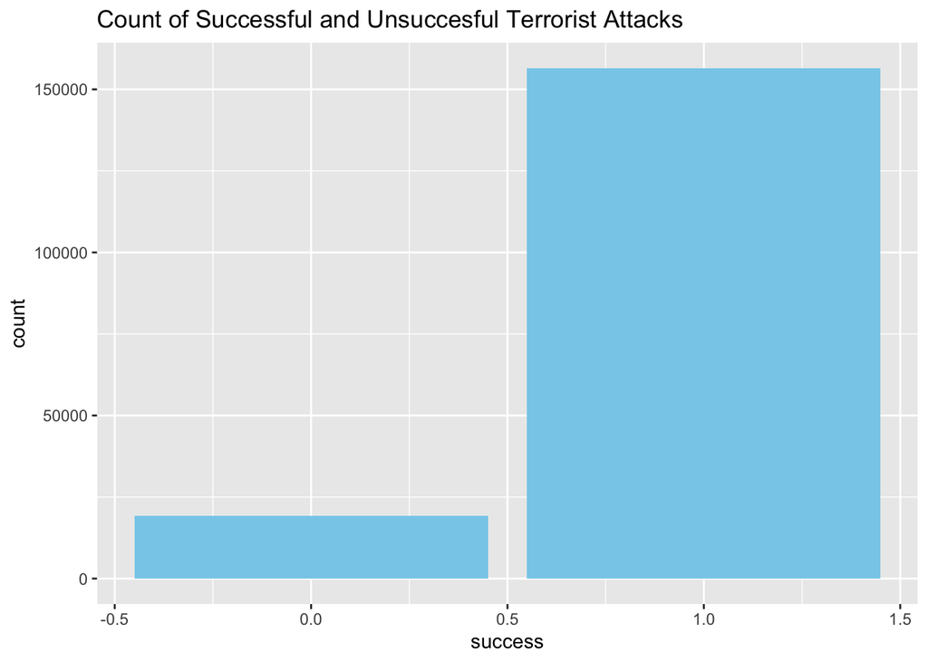

There are many more successful attacks than there are succesful ones.

Comparing the mean values of durable and Polity score for successful and unsuccessful attacks. This will give an idea of whether there is a noticeable difference in political stability factors based on the success of the attacks

| success | avg_durable | avg_polity |
| --- | --- | --- |
| 0 | 24.78148 | 5.439127 |
| 1 | 18.60135 | 4.648453 |

Visualizing the distribution of durable and Polity score across successful and unsuccessful attacks

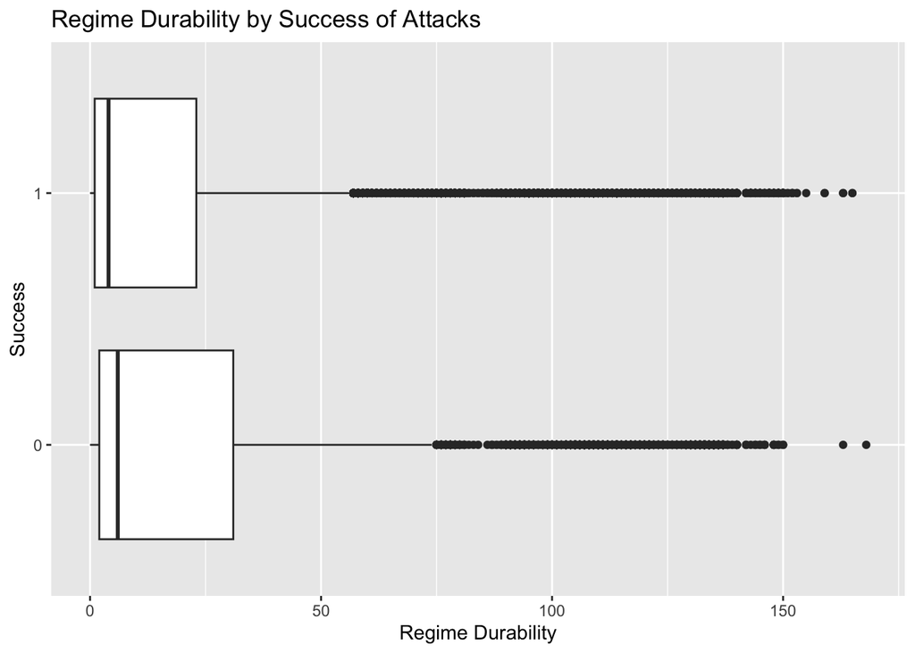

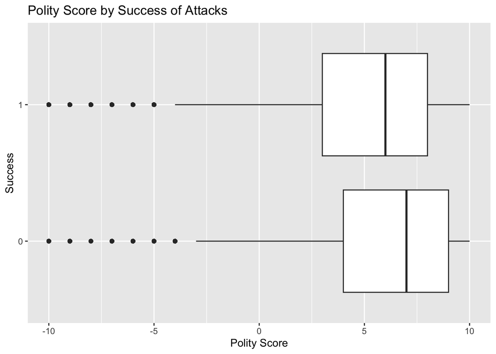

For attacks that are successful, the average durability of the country is lower for attacks that are unsuccesful.A country is more durable the longer it has been since a regime change which mean more durable countries are likely to have better infrastructure and communication through the country. This means they are better prepared to predict attacks, handle attacks, and send out first responders when needed. Successful attacks occur on average in a country with a lower Polity score. Since countries that have a higher Polity score are more democratic, the policies and authority in these countries tend to focus on protecting the public and civilians more than in autocratic governments.

How do polity score and durable score together influence the success of an attack?

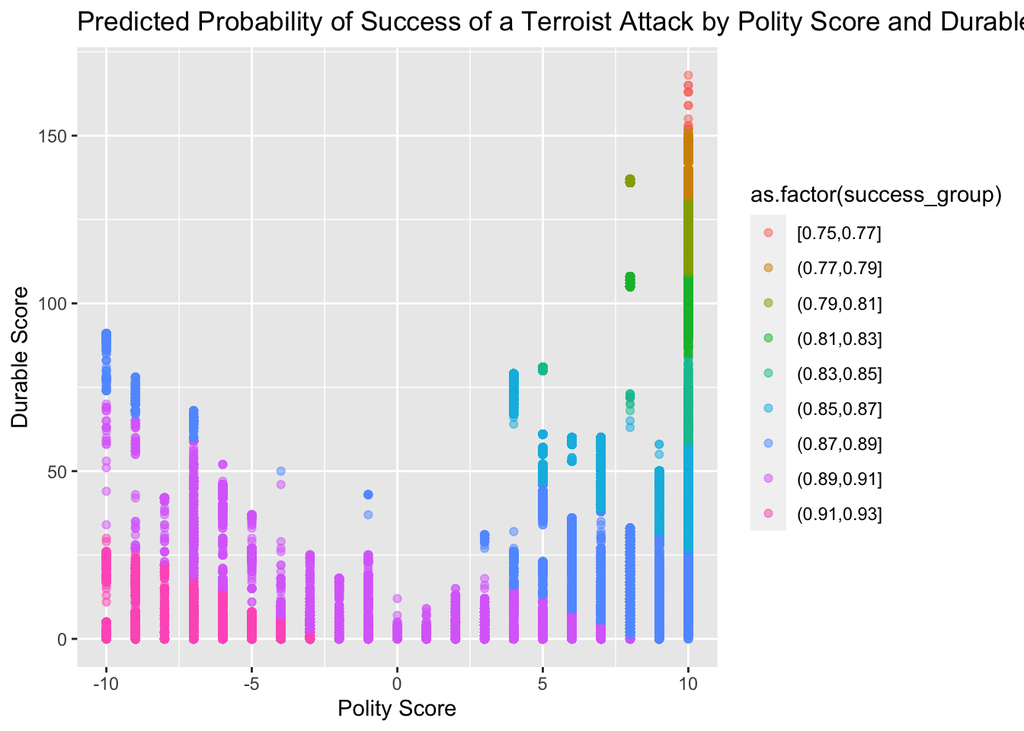

## Exploring Severity of Terroist Attacks by Weapon Type

Severity can be defined as rate of success and number of people killed and wounded by an attack

Does the type of weapon a terrorist chooses influence how likely they are to be succesful?

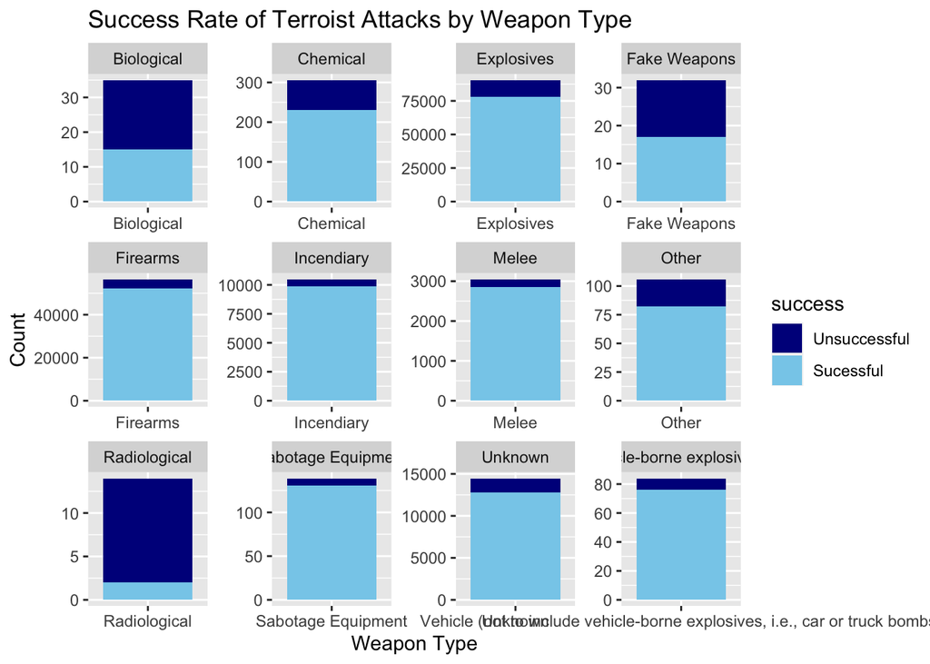

It appears that an attacker’s weapon of choice could have a very big impact on whether or not they will be successful. The weapons with the highest rate of success ppear to be attacks using. incendiaries. sabotage equipment, and melee. It is interesting to note that fake weapons has a higer success average than using biological weapons and radiological weapons. This may be due to the difficulty of creating an effective biological/ radiological weapon- advanced science knowledge would be required and resources, such as dangerous viruse and radioactive material, are hard to obtain.

From this, we can also tell that the most common weapon choice among terrorist attacks are explosives and the least common are radiological. It is interesting to note that explosives have a very high rate of success while radiological weapons have an extremely low rate of success.

Do the average amount of people killed and wounded vary among which weapon an attacker chose?

| weaptype1_txt | avg_kill | avg_wound | avg_kill_wound |
| --- | --- | --- | --- |
| Vehicle (not to include vehicle-borne explosives, i.e., car or truck bombs) | 37.4642857 | 209.7407407 | 248.4938272 |
| Chemical | 2.0802676 | 47.9512195 | 49.8675958 |
| Biological | 0.2647059 | 25.1562500 | 25.4375000 |
| Explosives | 1.9882156 | 4.4955439 | 6.2796674 |
| Melee | 3.2044696 | 1.6564912 | 4.5947759 |
| Firearms | 3.1922098 | 1.4647694 | 4.3543075 |
| Unknown | 3.3194049 | 1.4326144 | 4.1234854 |
| Sabotage Equipment | 0.6014493 | 2.1185185 | 2.6444444 |
| Other | 1.1538462 | 1.0396040 | 2.1980198 |
| Incendiary | 0.4670076 | 0.5072567 | 0.8225955 |
| Radiological | 0.1428571 | 0.2857143 | 0.4285714 |
| Fake Weapons | 0.0312500 | 0.0000000 | 0.0312500 |

Grouping by type of weapon used, we can see the severity of attacks varies greatly. Attack using a vehicle kills and wounds an average of 249 people while using fake weapons kills and wounds an average of 0.031 people.

## Progress Summary and Moving Forward

Regarding data collecting and cleaning, I have cleaned by datasets and joined them into one which I have been using to work on my project. For my EDA, I plan to have a basic overview section followed by two in depth explorations and then an findings section to explore some smaller variables I found interesting but couldn’t incorporate into my two larger explorations. The two explorations I am including are attack success vs political stability and severity of attacks vs weapon types. For each topic, I will do univariate, bivariate, and multivariate analysises and write a section summary of my findings. I have a rough analysis done for my basic overview section, most of my first exploration topic, and some of my second exploration topic.

I plan to include a multivariate analysis for my second exploration. Some of the relationships I am considering for this exploration are - does weapon choice affect total damage (people killed/ wounded, property damage)? - is success correlated to how many people are killed/ injured and how does this vary among weapo groups?

Some variables I find interesting but couldnt include in my two explorations are the variables on hostages and what are the most likey groups to be targeted. I may explore these in a smaller section for my own curosity. Questions I have include - Does taking hostages increase a terrorist’s chance of success? - Are attacks targeting public figures/ institutions/ people more successful and how does the choice of weapon differ between these.